# Análisis de datos: Supuestos de estadística paramétrica

Emma Y. Botello-Estrada

2022-11-17

# Cargando las librerias a usar

R tiene un amplio catálogo de librerias que pueden extender las funciones a emplear en el ambiente de trabajo. La forma básica de usarlas es instalando el paquete externo ejecutando una vez el comando `install.packages()` y luego llamando el paquete al ambiente de trabajo cada vez que sea necesario empleando al incio de un script la función `library()`. Sin embargo, el paquete `pacman` con su función `p_load()` permite en un solo comando instalar las librerías que no se tenga y cargarlas al ambiente de trabajo.

Esta es la forma clásica:

```r
install.packages("tidyverse")
library(tidyverse)
```

Vamos a optar por este uso:

```r
if (!require("pacman")) install.packages("pacman")
pacman::p_load(tidyverse, nortest, ggplot2,car)
```

# Cargando datos en RStudio

Se pueden usar funciones que inician con “read” para cargar datos, por ejemplo `read.csv()` o la función `read_xlsx()` del paquete `readxl`.

Con estas funciones R suele cargar el objeto como tipo de dato “data.frame”, que es un formato donde es posible combinar en un solo objeto datos de otros tipos (character, integer, numeric, logical, factor). Se puede comprobar la estructura usando la función `str()`.

```r
BD <- read.csv(file = "../Data/data.csv")
str(BD)
```

```
## 'data.frame':    25 obs. of  9 variables:
##  $ ID            : chr  "E_AM_S1_M" "E_AM_S2_NA" "E_AM_S3_NA" "E_AM_S4_H" ...
##  $ Sexo_Aplicador: chr  "M" "M" "M" "M" ...
##  $ Sexo          : chr  "M" NA NA "H" ...
##  $ Chiste_1      : int  0 NA NA 0 0 NA NA NA 1 0 ...
##  $ Chiste_2      : int  1 NA NA 0 0 NA NA NA 1 0 ...
##  $ Chiste_3      : int  0 NA NA 1 0 NA NA NA 1 0 ...
##  $ Chiste_4      : int  1 NA NA 1 1 NA NA NA 1 1 ...
##  $ Chiste_5      : int  0 NA NA 1 0 NA NA NA 1 0 ...
##  $ Veces_Risa    : int  2 NA NA 3 1 NA NA NA 5 1 ...
```

Eliminamos participantes con datos faltantes:

```r
BD <- na.omit(BD)
```

# Obteniendo descriptivos

Para comenzar a explorar los datos de una variable es conveniente calcular las medidas de estadística descriptiva. Se puede hacer esto empleando la función `group_by()` para resumir los datos por grupo usando también `summarise()`

```r
BD %>% group_by(Sexo_Aplicador) %>% summarise(
  media= mean(Veces_Risa),
  mediana= median(Veces_Risa),
  ds= sd(Veces_Risa),
  varianza= var(Veces_Risa),
  minimo= min(Veces_Risa),
  maximo= max(Veces_Risa),
  muestra= n(),
  error_estandar=ds/sqrt(muestra),
  i_confianza_low= media-2*error_estandar,
  i_confianza_up= media+2*error_estandar
)
```

```
## # A tibble: 2 × 11
##   Sexo_Aplic…¹ media mediana    ds varia…² minimo maximo muestra error…³ i_con…⁴
##   <chr>        <dbl>   <dbl> <dbl>   <dbl>  <int>  <int>   <int>   <dbl>   <dbl>
## 1 H             2.75       3  1.16    1.36      1      5       8   0.412   1.93
## 2 M             1.75       1  1.58    2.5       0      5       8   0.559   0.632
## # … with 1 more variable: i_confianza_up <dbl>, and abbreviated variable names
## #   ¹Sexo_Aplicador, ²varianza, ³error_estandar, ⁴i_confianza_low
```

```r
BD<- BD %>% mutate(ID_Card=1:16)
```

```r
set.seed(16) # Se pone una semilla para que siempre salga la misma selección a pesar de que se hace al azar
```

Para futuros ejercicios guardamos la base generada:

```r
write.csv(BD, file = "../Output/BD.csv")
```

# Normalidad y homocedasticidad de los datos

```r
# Muestra menor a 50 participantes
shapiro.test(BD$Veces_Risa[BD$Sexo_Aplicador=="M"])
```

```
##
##  Shapiro-Wilk normality test
##
## data:  BD$Veces_Risa[BD$Sexo_Aplicador == "M"]
## W = 0.83955, p-value = 0.07452
```

```r
shapiro.test(BD$Veces_Risa[BD$Sexo_Aplicador=="H"])
```

```
##
##  Shapiro-Wilk normality test
##
## data:  BD$Veces_Risa[BD$Sexo_Aplicador == "H"]
## W = 0.89239, p-value = 0.2463
```

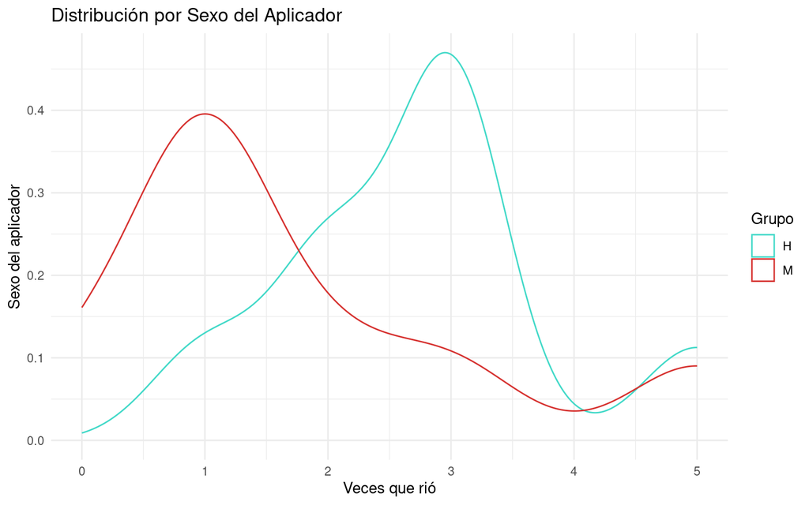

```r
ggplot(data= BD, aes(x=Veces_Risa, color=Sexo_Aplicador)) +
  geom_density() +
  scale_color_manual(values = c("#42D9C8","#D63230"))+
       theme_minimal()+
      labs(title = 'Distribución por Sexo del Aplicador',
       color = 'Grupo',
       x = 'Veces que rió',
       y='Sexo del aplicador')
```

Dado que los datos cumplen el supuesto de normalidad, se pone a prueba el supuesto de homocedasticidad con la prueba de Bartlett

```r
bartlett.test(BD$Veces_Risa ~ BD$Sexo_Aplicador)
```

```
##
##  Bartlett test of homogeneity of variances
##
## data:  BD$Veces_Risa by BD$Sexo_Aplicador
## Bartlett's K-squared = 0.60033, df = 1, p-value = 0.4385
```

Como el p-value es un valor mayor de 0.05, aceptamos la hipótesis nula (H0). Esto nos indica que nuestras dos muestras presentan varianzas iguales. Es decir: no se encuentran diferencias significativas entre las varianzas de los dos grupos.

Se observa este hallazgo visualmente:

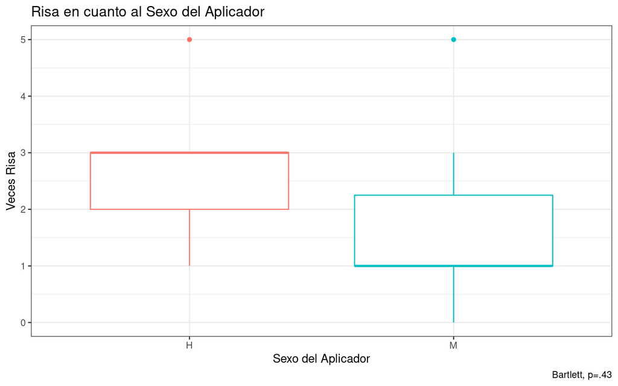

```r
ggplot(data = BD, aes(x = Sexo_Aplicador, y = Veces_Risa, colour = Sexo_Aplicador)) +
  geom_boxplot() +
  labs(
    title = 'Risa en cuanto al Sexo del Aplicador',
       x = 'Sexo del Aplicador',
       y = 'Veces Risa',
       caption="Bartlett, p=.43"
    ) +
  theme_bw() +
  theme(legend.position = "none")
```